# Assignment 03: Data Visualization, Markdown, and Git

Katie Guyot

14 February 2020

## About the Data

The American Time Use Survey is a nationally representative survey of the time use of individuals ages 15 and older. Data are recorded as time diaries in which respondents record what they did, where, and with whom over the previous day. Interviews take place every day of the year except a few major holidays. More information can be found at https://www.bls.gov/tus/overview.htm#1. The data extract used in this exercise was downloaded from IPUMS.

**Citation:**

*Sandra L. Hofferth, Sarah M. Flood and Matthew Sobek. American Time Use Survey Data Extract Builder: Version 2.7 [dataset]. College Park, MD: University of Maryland and Minneapolis, MN: IPUMS, 2018. https://doi.org/10.18128/D060.V2.7*

## Load Packages and Data

```r
atus <- read_csv("atus_00018.csv")
atus <- filter(atus, YEAR > 2013)

industries <- read_csv("industries.csv")
```

## Graph 1

What is the relationship between average weekly worktime and wage, by industry and the fraction of the industry that is female?

I first recode the relevant variables for analysis.

```r
atus <- left_join(atus, industries, by="IND2")

atus$UHRSWORKT[atus$UHRSWORKT == 9995] <- 9999

atus <- atus %>%
  mutate(EARNWEEK = na_if(EARNWEEK, 99999.99)) %>%
  mutate(UHRSWORKT = na_if(UHRSWORKT, 9999)) %>%
  mutate(wage = EARNWEEK/UHRSWORKT) %>%
  mutate(work_hrswkly = BLS_WORK_WORKING*7/60) %>%
  mutate(female = SEX-1)
```

I now create a new dataset of weighted average work hours and wages by industry. I also create variables to denote the fraction of the industry workforce that is female and how many people in the sample work in each industry.

```r
industry_worktime <- atus %>%
  filter(!is.na(wage) & !is.na(industry) &
           UHRSWORKT>0 & EARNWEEK>0) %>%
  select(YEAR, WT06, industry, wage,
         work_hrswkly, female) %>%
  group_by(industry) %>%
  summarize(avgwage = weighted.mean(wage, WT06, na.rm=TRUE),
            avghrs = weighted.mean(work_hrswkly, WT06, na.rm=TRUE),
            n=n(),
            fraction_female = weighted.mean(female, WT06, na.rm=TRUE))
```

The following lines create a scatterplot of average hourly wage and average weekly hours. The color of the bubbles denotes fraction of the industry workforce that is female, and the size of the bubbles indicates the number of workers employed in each industry (in the sample, not in the population).

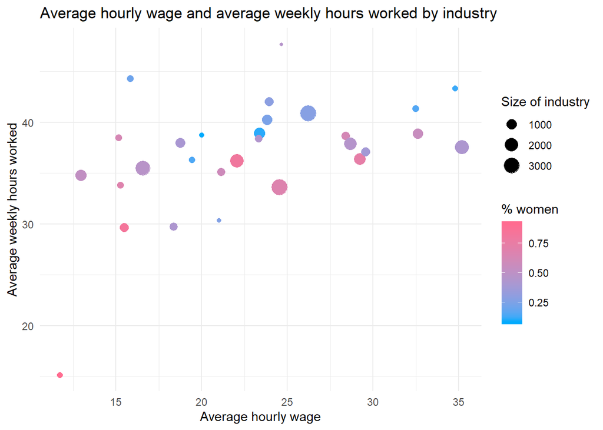

```r
ggplot(industry_worktime, mapping = aes(x = avgwage, y = avghrs)) +
  geom_point(mapping = aes(color = fraction_female, size = n)) +
  scale_color_gradient(low="#00ABFD", high="#FF6C90") +
  labs(color = "% women") +
  labs(x = "Average hourly wage") +
  labs(y = "Average weekly hours worked") +
  labs(title = "Average hourly wage and average weekly hours worked by industry") +
  labs(size = "Size of industry") +
  theme_minimal()
```

Average work hours are generally longer in male-dominated industries. From other research, we know that this is largely due to higher rates of part-time work among women, which is in turn the result of gendered hold and family responsibilities. Differences in average wages between male- and female-dominated industries in this data source are perhaps smaller than we would expect from data sources that are better used for measuring wages (e.g. CPS or NCS), as female-dominated industries tend to pay lower wages. The combination of lower work hours and lower pay will result in even greater disparities in total earnings.

## Graph 2

```r
parents <- atus %>%
  select(WT06, SEX, MARST, EMPSTAT, SPEMPSTAT, KIDUND18, BLS_CAREHH_KID) %>%
  filter(KIDUND18 > 0) %>%
  mutate(female = SEX - 1) %>%
  mutate(couple_type = ifelse(EMPSTAT %in% 1:2 & SPEMPSTAT %in% 1:2, "Dual earner",
                              ifelse(EMPSTAT %in% 1:2 & SPEMPSTAT %in% 3:6, "Breadwinner",
                                     ifelse(EMPSTAT %in% 3:5 & SPEMPSTAT %in% 1:2,
                                            "Homemaker",
                                            ifelse(SPEMPSTAT==99, "Single parent",
                                                   ifelse(EMPSTAT %in% 3:5 & SPEMPSTAT %in% 3:6, "No workers",
                                                   "Unknown"))))))
```

Collapse parent dataset into average time in certain activities by type of family. The sample is limited to people who fall into one of the following categories: breadwinner (married and employed, spouse is not employed); dual earner (married, both spouses are employed); homemaker (married and not employed, spouse is employed); and single parent (not married, any employment status). Averages are calculated by gender and family role, but I then regroup the data by gender to calculate the fraction of the weighted sample of men or women who fall into each category.

```r
parents <- parents %>%
  group_by(female, couple_type) %>%
  summarise(childcare = weighted.mean(BLS_CAREHH_KID, WT06, na.rm=TRUE),
            count = n(), sum_weights = sum(WT06, na.rm = TRUE)) %>%
  filter(!couple_type == "No workers") %>%
  filter(!couple_type == "Unknown") %>%
  ungroup() %>%
  mutate(frac=100*round(sum_weights/sum(sum_weights),3)) %>%
  mutate(gender = ifelse(female == 0, "Fathers", "Mothers"))
```

Now produce the graph of mean daily minutes in childcare by stereotypical family role:

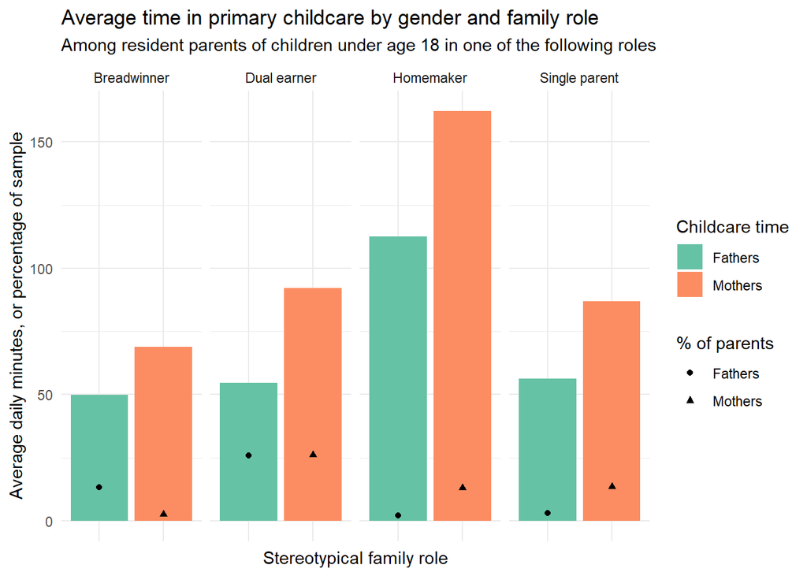

```r
ggplot(parents) +
  geom_col(mapping = aes(x = gender, y = childcare, fill = factor(gender))) +
  geom_point(mapping = aes(x = gender, y = frac, shape = factor(gender))) +
  scale_fill_brewer(palette="Set2") +
  facet_grid(~ couple_type) +
  labs(y = "Average daily minutes, or percentage of sample",
       x = "Stereotypical family role" ,
       title = "Average time in primary childcare by gender and family role" ,
       subtitle = "Among resident parents of children under age 18 in one of the following roles" ,
       fill = "Childcare time",
       shape = "% of parents") +
  theme_minimal() +
  theme(axis.text.x=element_blank(),
        axis.ticks.x=element_blank())
```

Here’s an alternative (and I think better) version of the second plot that stacks the two plots instead of superimposing them:

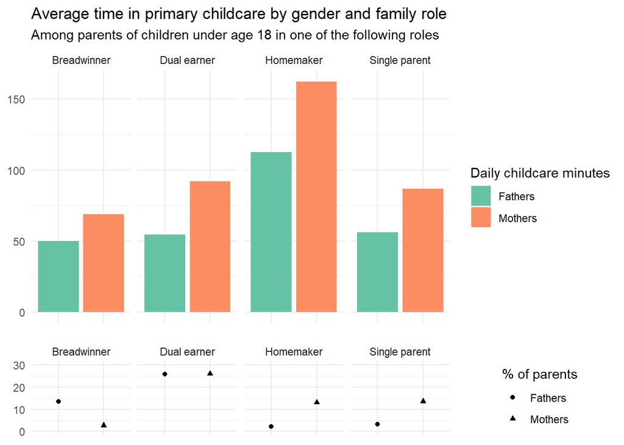

```r
p1 <- ggplot(parents) +
  geom_col(mapping = aes(x = gender, y = childcare, fill = gender)) +
  scale_fill_brewer(palette="Set2") +
  facet_grid(~ couple_type) +
  labs(title = "Average time in primary childcare by gender and family role" ,
       subtitle = "Among parents of children under age 18 in one of the following roles",
       fill = "Daily childcare minutes") +
  theme_minimal() +
  theme(axis.text.x=element_blank(),
        axis.ticks.x=element_blank(),
        axis.title.y = element_blank(),
        axis.title.x = element_blank())

p2 <- ggplot(parents) +
  geom_point(mapping = aes(x = gender, y = frac, shape = gender)) +
  facet_grid(~ couple_type) +
  labs(shape = "% of parents") +
  theme_minimal() +
  expand_limits(y = c(0, 30)) +
  theme(axis.text.x=element_blank(),
        axis.ticks.x=element_blank(),
        axis.title.x = element_blank(),
        axis.title.y = element_blank())

plot_grid(p1, p2, align = "v", ncol = 1, rel_heights = c(3, 1))
```

## Graph 3

I now look at the distribution of leisure time by educational group. Leisure time is distributed across person days, not people; therefore, variation is day-to-day as well as person-to-person.

```r
education <- atus %>%
  filter(AGE %in% 25:54) %>%
  select(BLS_LEIS, EDUC, WT06) %>%
  mutate(BLS_LEIS = BLS_LEIS*7/60) %>%
  mutate(educ_r = ifelse(EDUC %in% 10:17, "Less than HS",
                         ifelse(EDUC %in% 20:21, "HS",
                          ifelse(EDUC %in% 30:32, "Some college",
                           ifelse(EDUC == 40, "BA",
                            "Graduate degree")))))
```

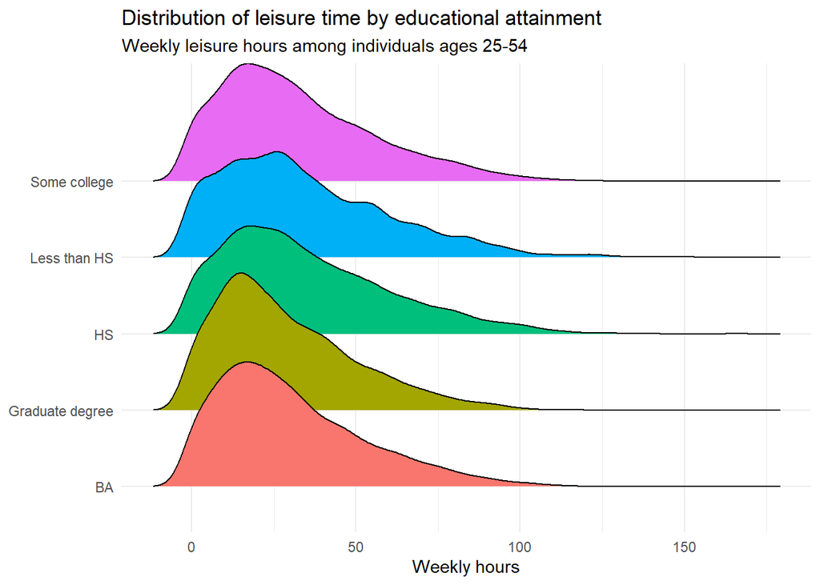

```r
ggplot(data = education, aes(x = BLS_LEIS, y = educ_r, fill = educ_r)) +
  geom_density_ridges() +
  theme_minimal() +
  theme(legend.position = "none") +
  labs(title = "Distribution of leisure time by educational attainment" ,
       subtitle = "Weekly leisure hours among individuals ages 25-54",
       x = "Weekly hours") +
  theme(axis.title.y = element_blank())
```